# Data Visualization with ggplot2

James Naphtali

11/15/2018

# 1 Introduction

- Exploratory Plots - Data visualization and analyses intended for a specialist audience studying the dataset. It is a rough draft of the final presentation of a plot.
- Explanatory Plots - Intended for a broader audience, presentable for the general public. It is the final copy of plots with proper formatting and analyzed with all necessary statistical treatments.

## 1.1 Exploring ggplot2, part 1

Import and generate ggplot of mtcars dataset

```r
# Load the ggplot2 package
library(ggplot2)
library(magrittr)
library(tidyr)
library(dplyr)
# Explore the mtcars data frame with str()
str(mtcars)
```

```
## 'data.frame':    32 obs. of  11 variables:
##  $ mpg : num  21 21 22.8 21.4 18.7 18.1 14.3 24.4 22.8 19.2 ...
##  $ cyl : num  6 6 4 6 8 6 8 4 4 6 ...
##  $ disp: num  160 160 108 258 360 ...
##  $ hp  : num  110 110 93 110 175 105 245 62 95 123 ...
##  $ drat: num  3.9 3.9 3.85 3.08 3.15 2.76 3.21 3.69 3.92 3.92 ...
##  $ wt  : num  2.62 2.88 2.32 3.21 3.44 ...
##  $ qsec: num  16.5 17 18.6 19.4 17 ...
##  $ vs  : num  0 0 1 1 0 1 0 1 1 1 ...
##  $ am  : num  1 1 1 0 0 0 0 0 0 0 ...
##  $ gear: num  4 4 4 3 3 3 3 4 4 4 ...
##  $ carb: num  4 4 1 1 2 1 4 2 2 4 ...
```

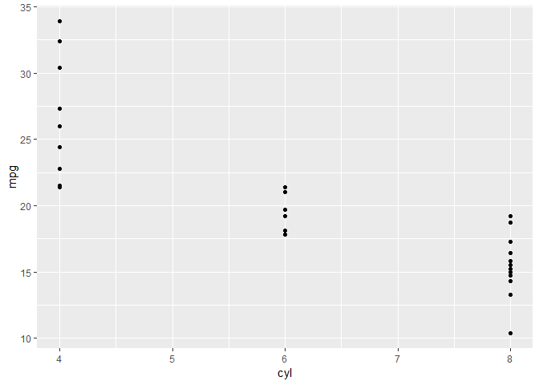

```r
# Execute the following command
ggplot(mtcars, aes(x = cyl, y = mpg)) +
  geom_point()
```

‘cyl’ variable was treated as a numeric (continuous) variable, instead of a categorical variable

## 1.2 Exploring ggplot2, part 2

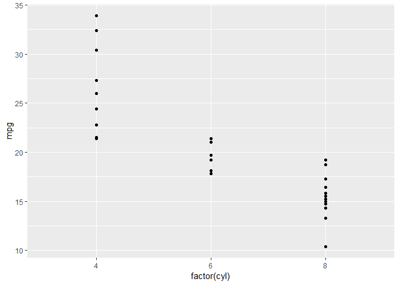

```r
# Load the ggplot2 package
library(ggplot2)

# Change the command below so that cyl is treated as factor
ggplot(mtcars, aes(x = factor(cyl), y = mpg)) +
  geom_point()
```

Converted `cyl` to a categorical variable on the x-axis of the scatter plot.

## 1.3 Grammar of Graphics

2 Principles

- Graphics - distinct layers of grammatical elements
- Meaningful Plots through aesthetic mapping

Grammatical Elements

- Data: variables of interest
- Aesthetics: x-axis, y-axos, colour, fill, size, labels.
- Geometries: points, line, histogram, bar.
- Facets: columns, rows.
- Statistics: binning, smoothing, descriptive.
- Coordinates: cartesian, fixed, polar.
- Themes

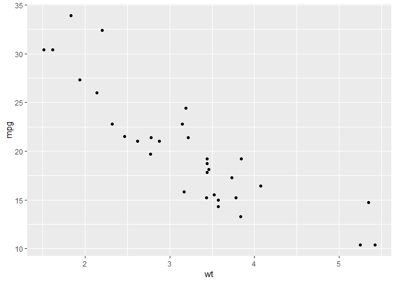

```r
# A scatter plot has been made for you
ggplot(mtcars, aes(x = wt, y = mpg)) +
  geom_point()
```

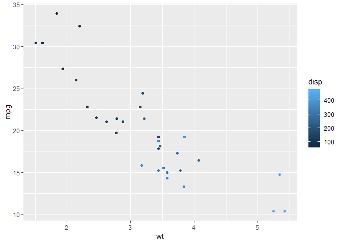

```r
# Replace ___ with the correct column
ggplot(mtcars, aes(x = wt, y = mpg, color = disp)) +
  geom_point()
```

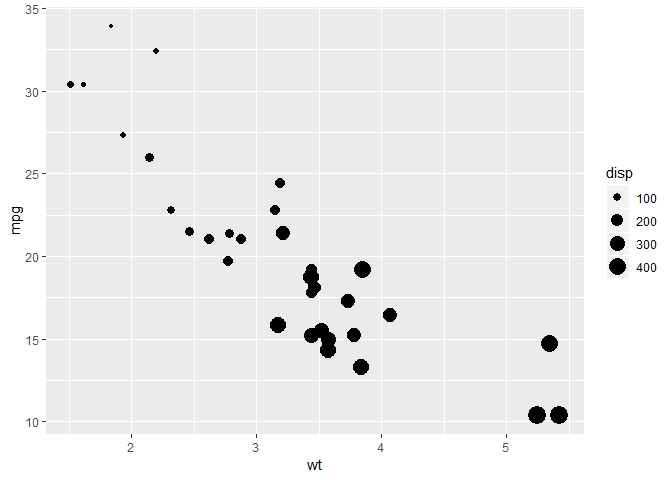

```r
# Replace ___ with the correct column
ggplot(mtcars, aes(x = wt, y = mpg, size = disp)) +
  geom_point()
```

For my project, determining the change of a bacterial species’ abundance over a continuous variable such as time or a chemical parameter can be performed using ggplot2’s scatter plot abilities

## 1.4 Understanding Variables

Certain arguments within ggplot2 such as `shape` require specific types of variables. In the case of `shape` to obtain the shape of points, it requires categorical data.

## 1.5 ggplot2 layers

1. Data: will use `iris` dataset
2. Aesthetics: mapping of data, ex. scatter plot of `sepal.width` vs. `sepal.length`
3. Geometry: How the plot looks
4. Facets: How to split up our plots (scatter plot for each category for example)
5. Statistics: what model to apply on the data
6. Coordinates: Scaling of visualized data
7. Theme: appearance of all non-data parts of the plot

## 1.6 Exploring ggplot2, part 4

```r
# Explore the diamonds data frame with str()
str(diamonds)
```

```
## Classes 'tbl_df', 'tbl' and 'data.frame':    53940 obs. of  10 variables:
##  $ carat  : num  0.23 0.21 0.23 0.29 0.31 0.24 0.24 0.26 0.22 0.23 ...
##  $ cut    : Ord.factor w/ 5 levels "Fair"<"Good"<..: 5 4 2 4 2 3 3 3 1 3 ...
##  $ color  : Ord.factor w/ 7 levels "D"<"E"<"F"<"G"<..: 2 2 2 6 7 7 6 5 2 5 ...
##  $ clarity: Ord.factor w/ 8 levels "I1"<"SI2"<"SI1"<..: 2 3 5 4 2 6 7 3 4 5 ...
##  $ depth  : num  61.5 59.8 56.9 62.4 63.3 62.8 62.3 61.9 65.1 59.4 ...
##  $ table  : num  55 61 65 58 58 57 57 55 61 61 ...
##  $ price  : int  326 326 327 334 335 336 336 337 337 338 ...
##  $ x      : num  3.95 3.89 4.05 4.2 4.34 3.94 3.95 4.07 3.87 4 ...
##  $ y      : num  3.98 3.84 4.07 4.23 4.35 3.96 3.98 4.11 3.78 4.05 ...
##  $ z      : num  2.43 2.31 2.31 2.63 2.75 2.48 2.47 2.53 2.49 2.39 ...
```

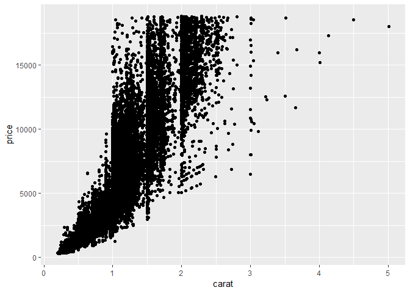

```r
# Add geom_point() with +
ggplot(diamonds, aes(x = carat, y = price)) + geom_point()
```

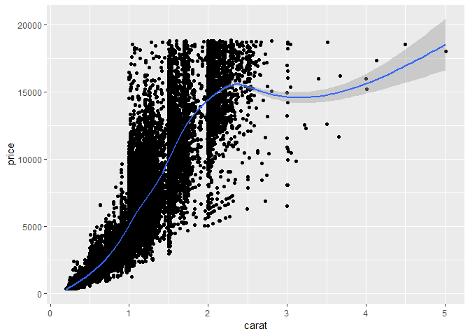

```r
# Add geom_point() and geom_smooth() with +
ggplot(diamonds, aes(x = carat, y = price)) + geom_point() + geom_smooth()
```

## 1.7 Exploring ggplot2, part 5

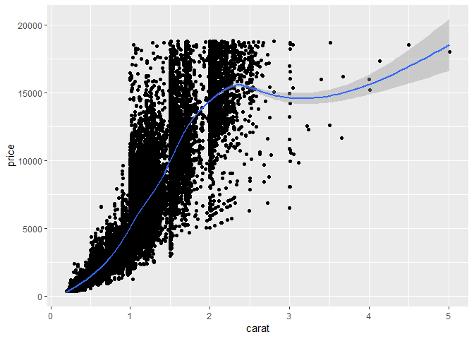

```r
# 1 - The plot you created in the previous exercise
ggplot(diamonds, aes(x = carat, y = price)) + geom_point() +
  geom_smooth()
```

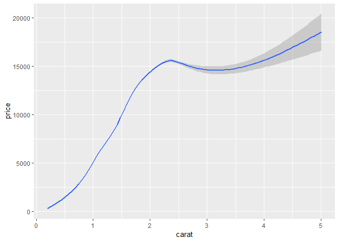

```r
# 2 - Copy the above command but show only the smooth line
ggplot(diamonds, aes(x = carat, y = price)) +
  geom_smooth()
```

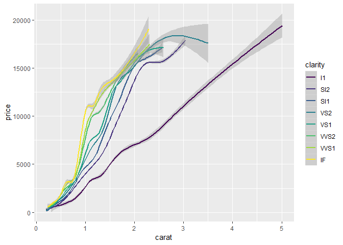

```r
# 3 - Copy the above command and assign the correct value to col in aes()
ggplot(diamonds, aes(x = carat, y = price, color = clarity)) +
  geom_smooth()
```

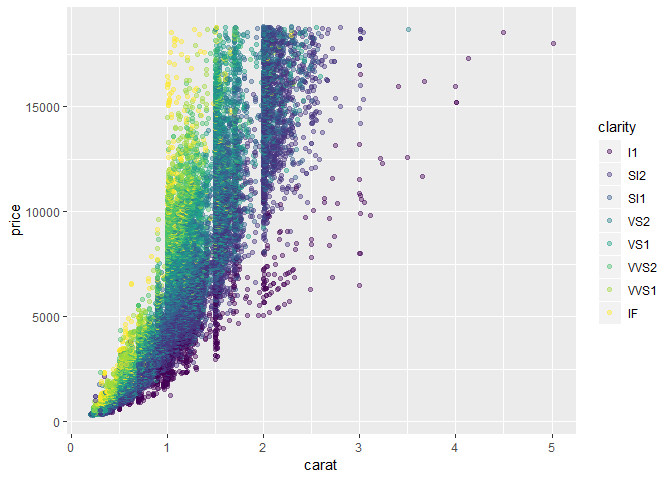

```r
# 4 - Keep the color settings from previous command. Plot only the points with argument alpha.
ggplot(diamonds, aes(x = carat, y = price, color = clarity)) +
  geom_point(alpha=0.4)
```

## 1.8 Understanding the grammar, part 1

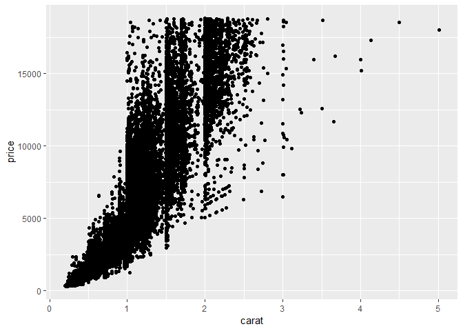

```r
# Create the object containing the data and aes layers: dia_plot
dia_plot <- ggplot(diamonds, aes(x = carat, y = price))

# Add a geom layer with + and geom_point()
dia_plot + geom_point()
```

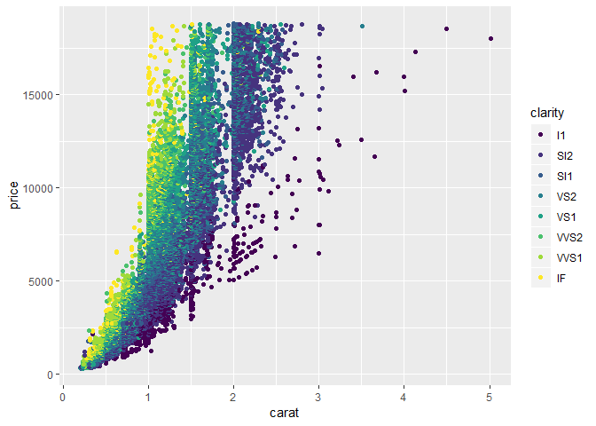

```r
# Add the same geom layer, but with aes() inside
dia_plot + geom_point(aes(color = clarity))
```

## 1.9 Understanding the grammar, part 2

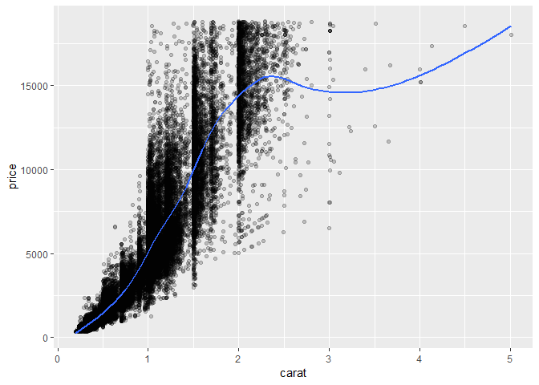

```r
# 1 - The dia_plot object has been created for you
dia_plot <- ggplot(diamonds, aes(x = carat, y = price))

# 2 - Expand dia_plot by adding geom_point() with alpha set to 0.2
dia_plot <- dia_plot + geom_point(alpha=0.2)

# 3 - Plot dia_plot with additional geom_smooth() with se set to FALSE
dia_plot + geom_smooth(se = FALSE)
```

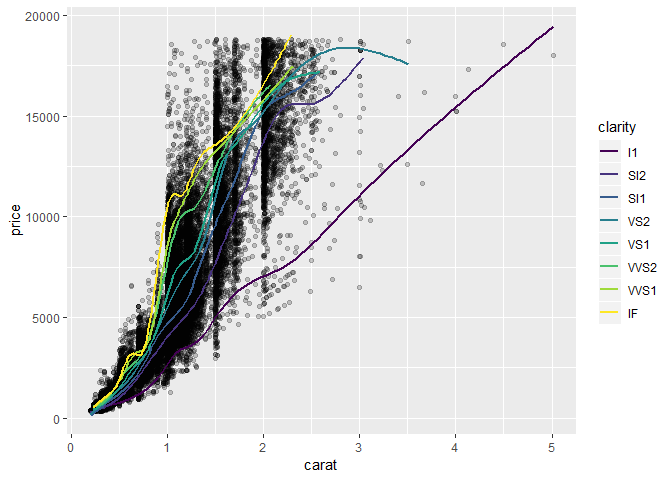

```r
# 4 - Copy the command from above and add aes() with the correct mapping to geom_smooth()
dia_plot + geom_smooth(aes(col = clarity), se = FALSE)
```

# 2 Plotting the Data Layer

For univariate and bivariate data, base plot package can achieve quick and clean plots.

Limitations of the base plot package

But for multivariate data, representing the factors is more difficult than using ggplot2.

- Plot does not get redrawn when adding data
- Plot is drawn as an image, not updatable as an object
- Need to manually add legend
- Plotting commands are not unified

## 2.1 base package and ggplot2, part 1 - plot

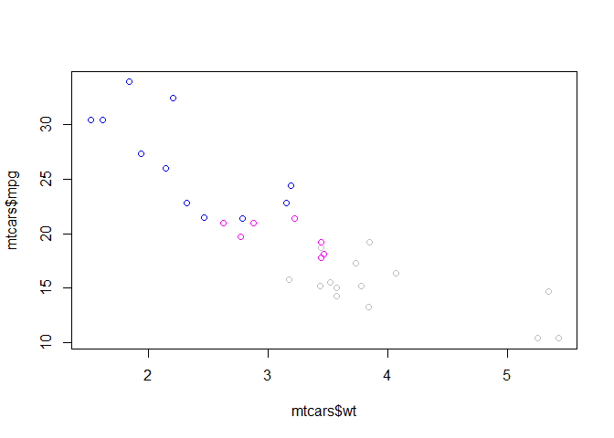

```r
# Plot the correct variables of mtcars
plot(mtcars$wt, mtcars$mpg, col = mtcars$cyl)
```

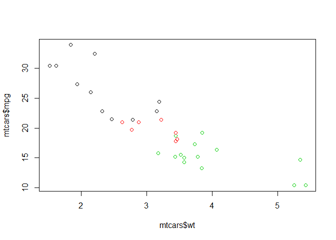

```r
# Change cyl inside mtcars to a factor
mtcars$fcyl <- as.factor(mtcars$cyl)

# Make the same plot as in the first instruction
plot(mtcars$wt, mtcars$mpg, col = mtcars$fcyl)
```

Basically used the different cylinder # as a factor to color in points

## 2.2 base package and ggplot2, part 2 - lm

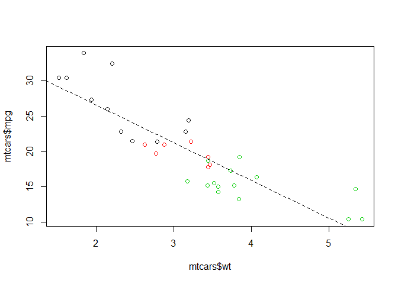

```r
# Use lm() to calculate a linear model and save it as carModel
carModel <- lm(mpg ~ wt, data = mtcars)

# Basic plot
mtcars$cyl <- as.factor(mtcars$cyl)
plot(mtcars$wt, mtcars$mpg, col = mtcars$cyl)

# Call abline() with carModel as first argument and set lty to 2
abline(carModel, lty = 2)
```

```r
# Plot each subset efficiently with lapply
# You don't have to edit this code
plot(mtcars$wt, mtcars$mpg, col = mtcars$cyl)
lapply(mtcars$cyl, function(x) {
  abline(lm(mpg ~ wt, mtcars, subset = (cyl == x)), col = x)
  })
```

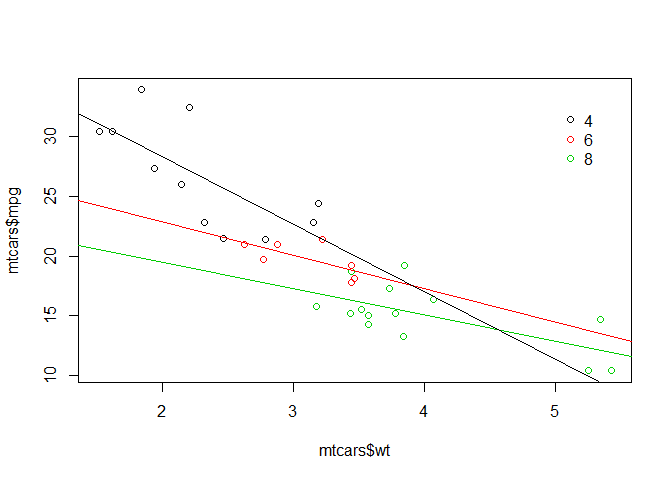

```r
# This code will draw the legend of the plot
# You don't have to edit this code
legend(x = 5, y = 33, legend = levels(mtcars$cyl),
       col = 1:3, pch = 1, bty = "n")
```

## 2.3 base package and ggplot2, part 3

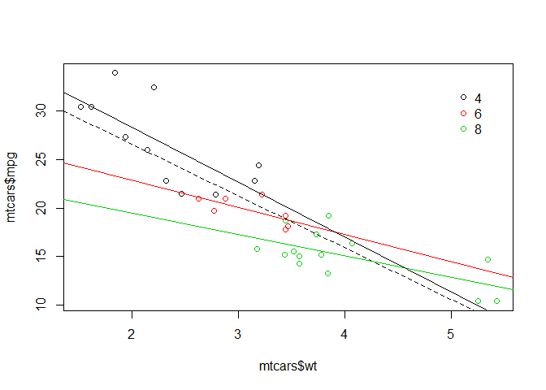

```r
# Convert cyl to factor (don't need to change)
mtcars$cyl <- as.factor(mtcars$cyl)

# Example from base R (don't need to change)
plot(mtcars$wt, mtcars$mpg, col = mtcars$cyl)
abline(lm(mpg ~ wt, data = mtcars), lty = 2)
lapply(mtcars$cyl, function(x) {
  abline(lm(mpg ~ wt, mtcars, subset = (cyl == x)), col = x)
  })
legend(x = 5, y = 33, legend = levels(mtcars$cyl),
       col = 1:3, pch = 1, bty = "n")
```

```r
# Plot 1: add geom_point() to this command to create a scatter plot
ggplot(mtcars, aes(x = wt, y = mpg, col = cyl)) +
  geom_point()  # Fill in using instructions Plot 1
```

[output not shown]

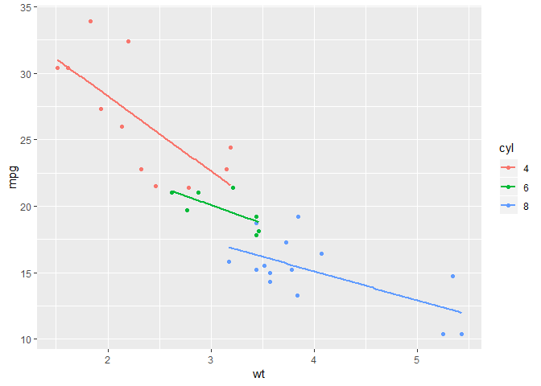

```r
# Plot 2: include the lines of the linear models, per cyl
ggplot(mtcars, aes(x = wt, y = mpg, col = cyl)) +
  geom_point()+ # Copy from Plot 1
  geom_smooth(method = 'lm', se = F)   # Fill in using instructions Plot 2
```

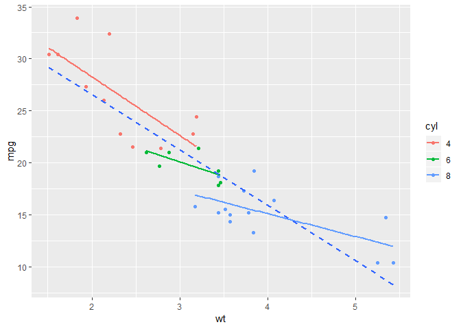

```r
# Plot 3: include a lm for the entire dataset in its whole
ggplot(mtcars, aes(x = wt, y = mpg, col = cyl)) +
  geom_point() + # Copy from Plot 2
  geom_smooth(method = 'lm', se = F) + # Copy from Plot 2
  geom_smooth(aes(group = 1), method = 'lm', se = F, linetype = 2)   # Fill in using instructions Plot 3
```

## 2.4 ggplot2 compared to base package

- it creates manipulatable objects
- simplifies customizing graph visualization options
- structured in an easy to understand “grammar of graphics”

## 2.5 Proper Data Format and Tidy Data

- Rearrange the dataset so that while plotting in ggplot2, the variables that are being plotted will be as clear as possible according to the function’s arguments. For example, individual observations (sample) should be placed row-wise and the columns should contain characteristics of each sample (ie. setosa/petal in the `iris.wide` dataset) as well as the measurements. Simplify multiple categorical variables into a single column.

## 2.6 Variables to visuals, part 1

```r
# Consider the structure of iris, iris.wide and iris.tidy (in that order)
str(iris)
```

```
## 'data.frame':    150 obs. of  5 variables:
##  $ Sepal.Length: num  5.1 4.9 4.7 4.6 5 5.4 4.6 5 4.4 4.9 ...
##  $ Sepal.Width : num  3.5 3 3.2 3.1 3.6 3.9 3.4 3.4 2.9 3.1 ...
##  $ Petal.Length: num  1.4 1.4 1.3 1.5 1.4 1.7 1.4 1.5 1.4 1.5 ...
##  $ Petal.Width : num  0.2 0.2 0.2 0.2 0.2 0.4 0.3 0.2 0.2 0.1 ...
##  $ Species     : Factor w/ 3 levels "setosa","versicolor",..: 1 1 1 1 1 1 1 1 1 1 ...
```

```r
iris$Flower <- 1:nrow(iris)
iris.wide <- iris %>%
  gather(key, value, -Flower, -Species) %>%
  separate(key, c("Part", "Measure"), "\\.") %>%
  spread(Measure, value)
str(iris.wide)
```

```
## 'data.frame':    300 obs. of  5 variables:
##  $ Species: Factor w/ 3 levels "setosa","versicolor",..: 1 1 1 1 1 1 1 1 1 1 ...
##  $ Flower : int  1 1 2 2 3 3 4 4 5 5 ...
##  $ Part   : chr  "Petal" "Sepal" "Petal" "Sepal" ...
##  $ Length : num  1.4 5.1 1.4 4.9 1.3 4.7 1.5 4.6 1.4 5 ...
##  $ Width  : num  0.2 3.5 0.2 3 0.2 3.2 0.2 3.1 0.2 3.6 ...
```

```r
iris.tidy <- iris %>%
  gather(key, Value, -Species) %>%
  separate(key, c("Part", "Measure"), "\\.")
str(iris.tidy)
```

```
## 'data.frame':    750 obs. of  4 variables:
##  $ Species: Factor w/ 3 levels "setosa","versicolor",..: 1 1 1 1 1 1 1 1 1 1 ...
##  $ Part   : chr  "Sepal" "Sepal" "Sepal" "Sepal" ...
##  $ Measure: chr  "Length" "Length" "Length" "Length" ...
##  $ Value  : num  5.1 4.9 4.7 4.6 5 5.4 4.6 5 4.4 4.9 ...
```

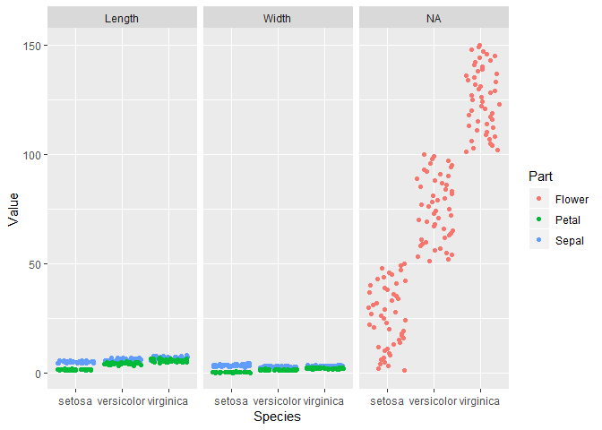

```r
# Think about which dataset you would use to get the plot shown right
# Fill in the ___ to produce the plot given to the right
ggplot(iris.tidy, aes(x = Species, y = Value, col = Part)) +
  geom_jitter() +
  facet_grid(. ~ Measure)
```

## 2.7 Variables to visuals, part 1b

```r
# Load the tidyr package
library(tidyr)

# Fill in the ___ to produce to the correct iris.tidy dataset
iris.tidy <- iris %>%
  gather(key, Value, -Species) %>%
  separate(key, c("Part", "Measure"), "\\.")
str(iris.tidy)
```

```
## 'data.frame':    750 obs. of  4 variables:
##  $ Species: Factor w/ 3 levels "setosa","versicolor",..: 1 1 1 1 1 1 1 1 1 1 ...
##  $ Part   : chr  "Sepal" "Sepal" "Sepal" "Sepal" ...
##  $ Measure: chr  "Length" "Length" "Length" "Length" ...
##  $ Value  : num  5.1 4.9 4.7 4.6 5 5.4 4.6 5 4.4 4.9 ...
```

## 2.8 Variables to visuals, part 2

```r
# The 3 data frames (iris, iris.wide and iris.tidy) are available in your environment
# Execute head() on iris, iris.wide and iris.tidy (in that order)
head(iris)
```

```
##   Sepal.Length Sepal.Width Petal.Length Petal.Width Species Flower
## 1          5.1         3.5          1.4         0.2  setosa      1
## 2          4.9         3.0          1.4         0.2  setosa      2
## 3          4.7         3.2          1.3         0.2  setosa      3
## 4          4.6         3.1          1.5         0.2  setosa      4
## 5          5.0         3.6          1.4         0.2  setosa      5
## 6          5.4         3.9          1.7         0.4  setosa      6
```

```r
head(iris.wide)
```

```
##   Species Flower  Part Length Width
## 1  setosa      1 Petal    1.4   0.2
## 2  setosa      1 Sepal    5.1   3.5
## 3  setosa      2 Petal    1.4   0.2
## 4  setosa      2 Sepal    4.9   3.0
## 5  setosa      3 Petal    1.3   0.2
## 6  setosa      3 Sepal    4.7   3.2
```

```r
head(iris.tidy)
```

```
##   Species  Part Measure Value
## 1  setosa Sepal  Length   5.1
## 2  setosa Sepal  Length   4.9
## 3  setosa Sepal  Length   4.7
## 4  setosa Sepal  Length   4.6
## 5  setosa Sepal  Length   5.0
## 6  setosa Sepal  Length   5.4
```

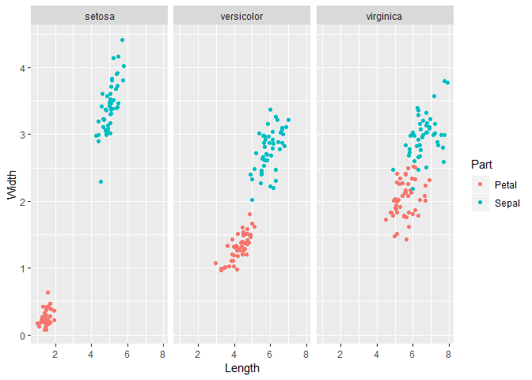

```r
# Think about which dataset you would use to get the plot shown right
# Fill in the ___ to produce the plot given to the right
ggplot(iris.wide, aes(x = Length, y = Width, color = Part)) +
  geom_jitter() +
  facet_grid(. ~ Species)
```

## 2.9 Variables to visuals, part 2b

```r
# Load the tidyr package
library(tidyr)

# Add column with unique ids (don't need to change)
iris$Flower <- 1:nrow(iris)

# Fill in the ___ to produce to the correct iris.wide dataset
iris.wide <- iris %>%
  gather(key, value, -Flower, -Species) %>%
  separate(key, c("Part", "Measure"), "\\.") %>%
  spread(Measure, value)
```

# 3 Aesthetics

## 3.1 Visible Aesthetics

- Aesthetics are mappings of a variable onto an axis, shape, color, size or other visual properties of the graph using the `aes()` function
- Aim is to keep X and Y axis consistent throughout a dataframe with many levels in categorical variables

## 3.2 All about Aesthetics, part 1

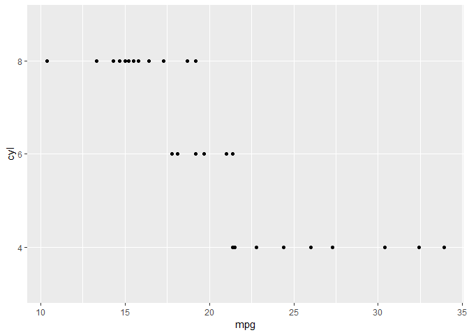

```r
# 1 - Map mpg to x and cyl to y
ggplot(mtcars, aes(mpg, cyl)) +
  geom_point()
```

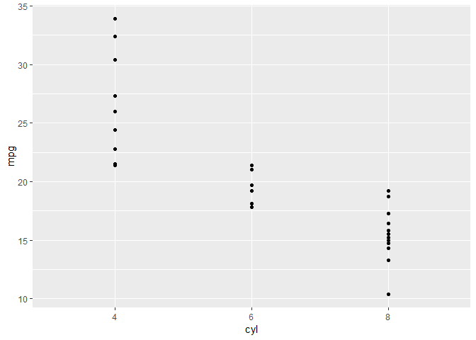

```r
# 2 - Reverse: Map cyl to x and mpg to y
ggplot(mtcars, aes(cyl, mpg)) +
  geom_point()
```

```r
# 3 - Map wt to x, mpg to y and cyl to col
ggplot(mtcars, aes(x=wt, y=mpg, col=cyl)) +
  geom_point()
```

[output not shown]

```r
# 4 - Change shape and size of the points in the above plot
ggplot(mtcars, aes(wt, mpg, col = cyl)) +
  geom_point(shape = 1, size = 4)
```

[output not shown]

## 3.3 All about aesthetics, part 2

```r
# am and cyl are factors, wt is numeric
class(mtcars$am)
```

```
## [1] "numeric"
```

```r
class(mtcars$cyl)
```

```
## [1] "factor"
```

```r
class(mtcars$wt)
```

```
## [1] "numeric"
```

```r
# From the previous exercise
ggplot(mtcars, aes(x = wt, y = mpg, col = cyl)) +
  geom_point(shape = 1, size = 4)
```

[output not shown]

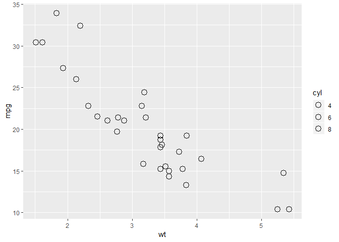

```r
# 1 - Map cyl to fill
ggplot(mtcars, aes(x = wt, y = mpg, fill = cyl)) +
  geom_point(shape = 1, size = 4)
```

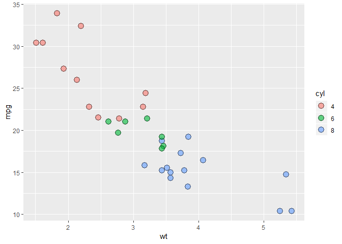

```r
# 2 - Change shape and alpha of the points in the above plot
ggplot(mtcars, aes(x = wt, y = mpg, fill = cyl)) +
  geom_point(shape = 21, size = 4, alpha= .6)
```

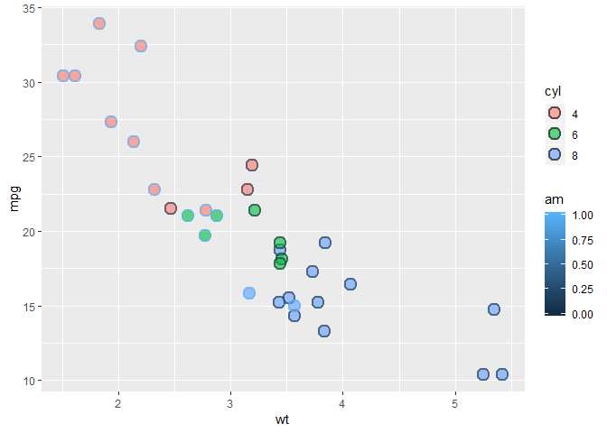

```r
# 3 - Map am to col in the above plot
ggplot(mtcars, aes(x = wt, y = mpg, fill = cyl, col = am)) +
  geom_point(shape = 21, size = 4, alpha= .6, stroke = 1.5)
```

## 3.4 All about aesthetics, part 3

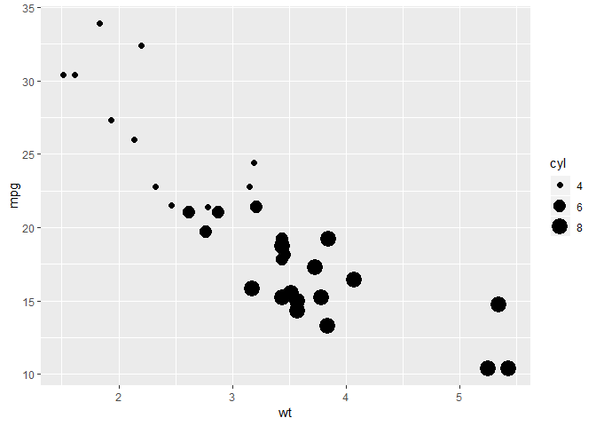

```r
# Map cyl to size
ggplot(mtcars, aes(wt, mpg, size = cyl)) + geom_point()
```

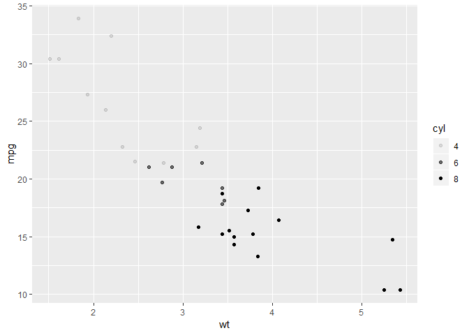

```r
# Map cyl to alpha
ggplot(mtcars, aes(wt, mpg, alpha = cyl)) + geom_point()
```

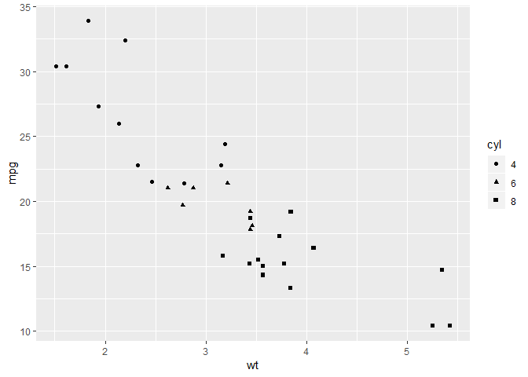

```r
# Map cyl to shape
ggplot(mtcars, aes(wt, mpg, shape = cyl)) + geom_point() ##This produces the clearest graph by relying on different shapes for classifying cyl variables
```

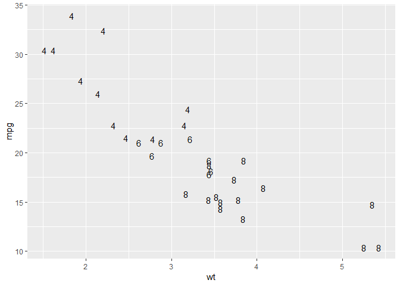

```r
# Map cyl to label
ggplot(mtcars, aes(wt, mpg, label = cyl)) + geom_text()
```

## 3.5 All about attributes, part 1

R has different `shapes` configurations  
- Shapes 1-20: accepts only `color` aesthetics - Shapes 21-25: can customize `color` and `fill`

```r
# Define a hexadecimal color
my_color <- "#4ABEFF"

# Draw a scatter plot with color *aesthetic*
ggplot(mtcars, aes(wt, mpg, col = cyl)) +
  geom_point()
```

[output not shown]

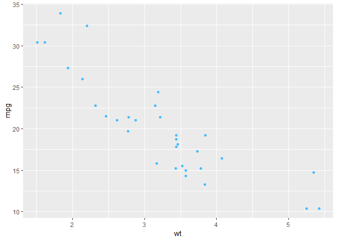

```r
# Same, but set color *attribute* in geom layer
ggplot(mtcars, aes(wt, mpg, col = cyl)) +
  geom_point(col=my_color)
```

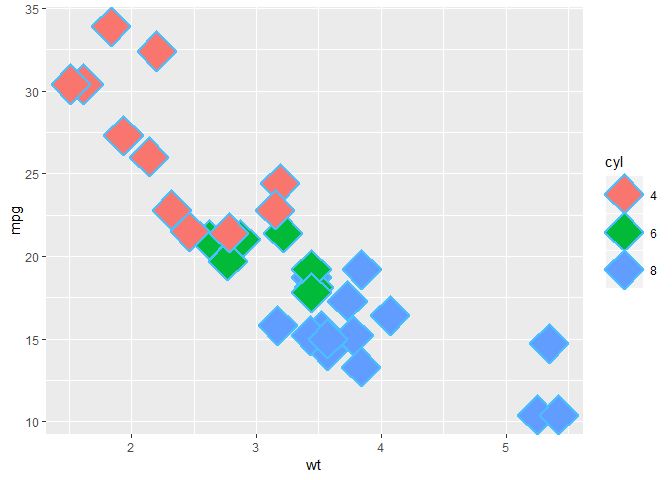

```r
# Set the fill aesthetic; color, size and shape attributes
ggplot(mtcars, aes(wt, mpg, fill = cyl)) +
  geom_point(size = 10, shape = 23, color = my_color, stroke = 1.5)
```

## 3.6 All about attributes, part 2

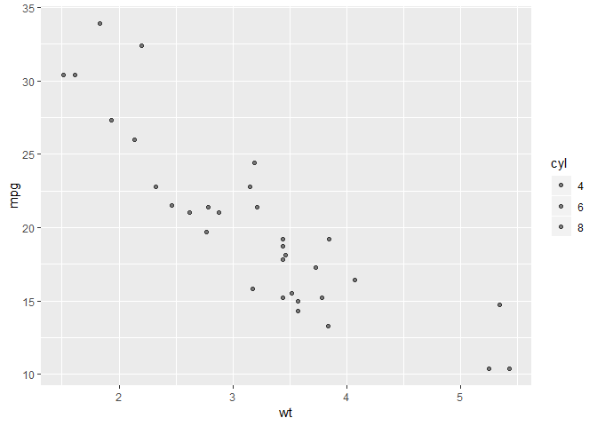

```r
# Expand to draw points with alpha 0.5
ggplot(mtcars, aes(x = wt, y = mpg, fill = cyl)) +
  geom_point(alpha = 0.5)
```

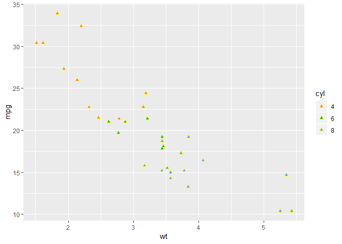

```r
# Expand to draw points with shape 24 and color yellow
ggplot(mtcars, aes(x = wt, y = mpg, fill = cyl)) +
  geom_point(shape = 24, color = 'yellow')
```

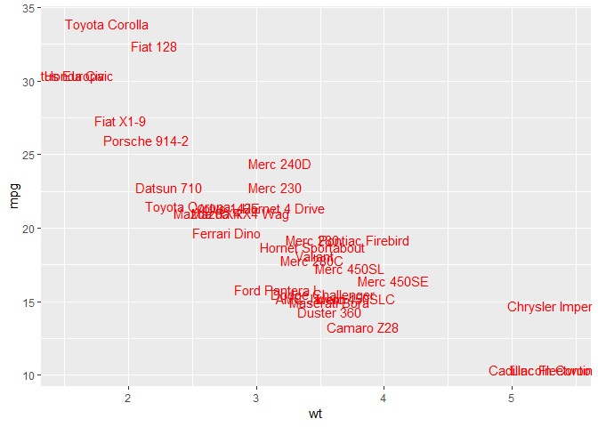

```r
# Expand to draw text with label rownames(mtcars) and color red
ggplot(mtcars, aes(x = wt, y = mpg, fill = cyl)) +
  geom_text(label = rownames(mtcars), color = 'red')
```

## 3.7 Going all out

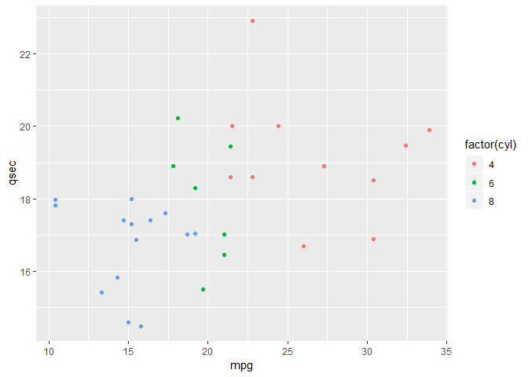

```r
# Map mpg onto x, qsec onto y and factor(cyl) onto col
ggplot(mtcars, aes(mpg, qsec, col = factor(cyl))) +
  geom_point()
```

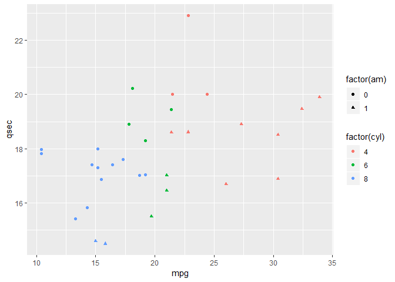

```r
# Add mapping: factor(am) onto shape
ggplot(mtcars,
  aes(mpg, qsec,
    col = factor(cyl),
    shape = factor(am)
    )) +
  geom_point()
```

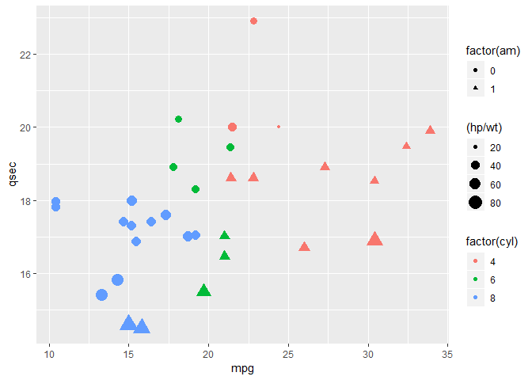

```r
# Add mapping: (hp/wt) onto size
ggplot(mtcars,
  aes(mpg, qsec,
    col = factor(cyl),
    shape = factor(am),
    size = (hp/wt)
    )) +
  geom_point()
```

## 3.8 Aesthetics for categorical and continuous variables

- `label` and `shape` arguments are only applicable to categorical data

## 3.9 Modifying Aesthetics

Position of data - Identity (categorical/continuous)  
- Dodge  
- stack  
- fill  
- jitter: introduce random noise and variation to the location of each point to alleviate overplotting - jitterdodge

## 3.10 Position

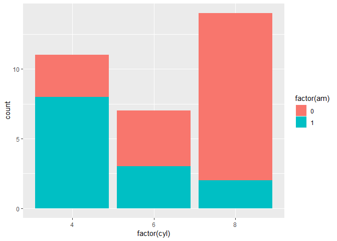

```r
cyl.am <- ggplot(mtcars, aes(x = factor(cyl), fill = factor(am)))
# The base layer, cyl.am, is available for you
# Add geom (position = "stack" by default)
cyl.am + geom_bar()
```

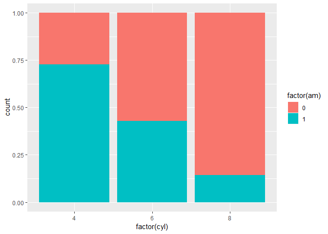

```r
# Fill - show proportion

cyl.am +  geom_bar(position = "fill")
```

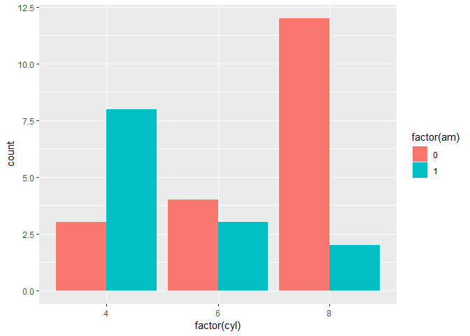

```r
# Dodging - principles of similarity and proximity
cyl.am +
  geom_bar(position = "dodge")
```

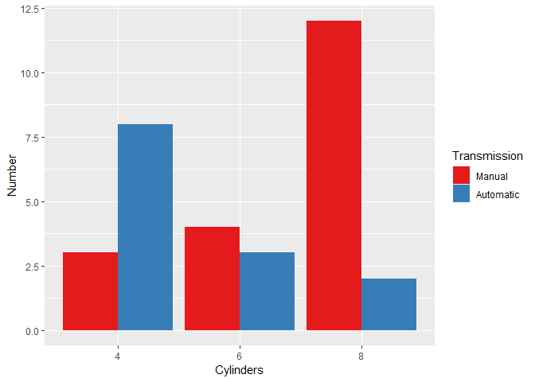

```r
# Clean up the axes with scale_ functions
val = c("#E41A1C", "#377EB8")
lab = c("Manual", "Automatic")
cyl.am +
  geom_bar(position = "dodge") +
  scale_x_discrete(name = "Cylinders") +
  scale_y_continuous(name = "Number") +
  scale_fill_manual(name = "Transmission",
                    values = val,
                    labels = lab)
```

## 3.11 Setting a dummy aesthetic

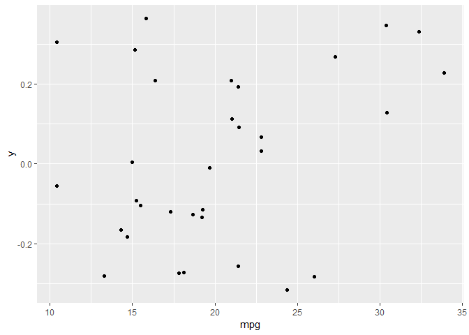

```r
## This will give an error because its missing y aesthetic
# ggplot(mtcars, aes(x = mpg)) + geom_point()

# 1 - Create jittered plot of mtcars, mpg onto x, 0 onto y
ggplot(mtcars, aes(x = mpg, y = 0)) +
  geom_jitter()
```

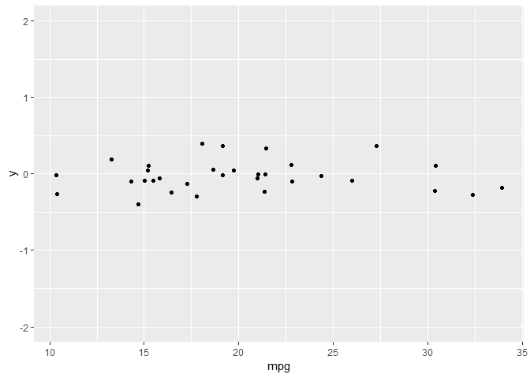

```r
# 2 - Add function to change y axis limits
ggplot(mtcars, aes(x = mpg, y = 0)) +
  geom_jitter() +
  scale_y_continuous(limits = c(-2,2))
```

## 3.12 Aethetics Best Practices

From lowest to highest accuracy of representing contiuous and categorical data

Continuous - Color, Grey-scale spectrum, point/length sizes, position on a common scale.

Categorical - Filled Shapes, sequential colors, qualitative colors.

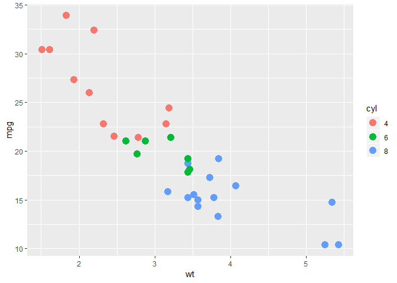

```r
##Overplotting 1  - Point shape and transparency
# Basic scatter plot: wt on x-axis and mpg on y-axis; map cyl to col
ggplot(mtcars, aes(wt, mpg, col = cyl)) +
  geom_point(size = 4)
```

```r
# Hollow circles - an improvement
ggplot(mtcars, aes(wt, mpg, col = cyl)) +
  geom_point(size = 4, shape = 1)
```

[output not shown]

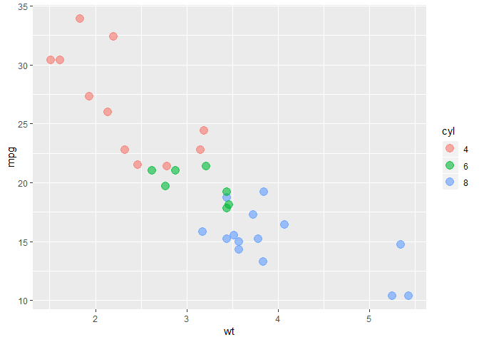

```r
# Add transparency - very nice
ggplot(mtcars, aes(wt, mpg, col = cyl)) +
  geom_point(size = 4, alpha = .6)
```

## 3.13 Overplotting 2 - alpha with large datasets

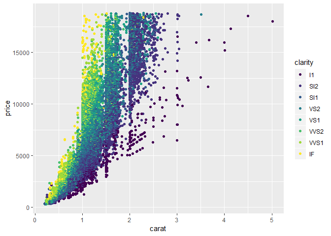

```r
# Scatter plot: carat (x), price (y), clarity (color)
ggplot(diamonds, aes(carat, price, col = clarity)) +
  geom_point()
```

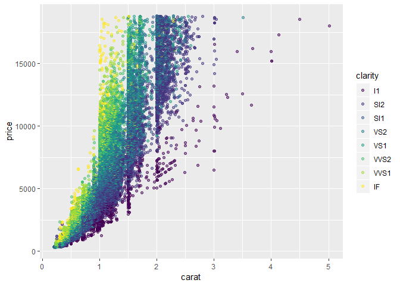

```r
# Adjust for overplotting
ggplot(diamonds, aes(carat, price, col = clarity)) +
  geom_point(alpha = 0.5)
```

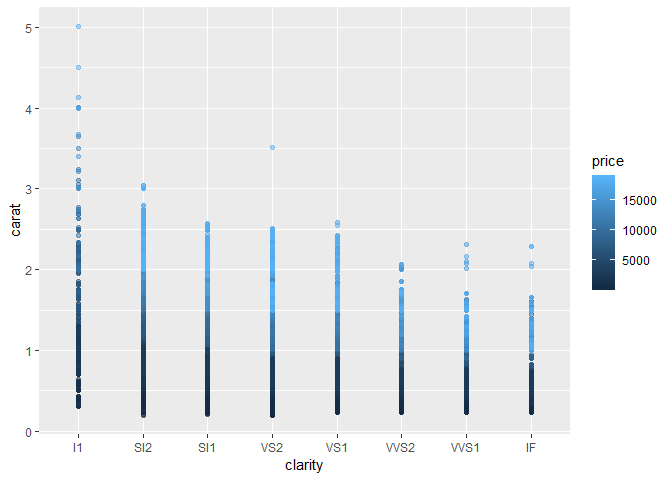

```r
# Scatter plot: clarity (x), carat (y), price (color)
ggplot(diamonds, aes(clarity, carat, col = price)) +
  geom_point(alpha = 0.5)
```

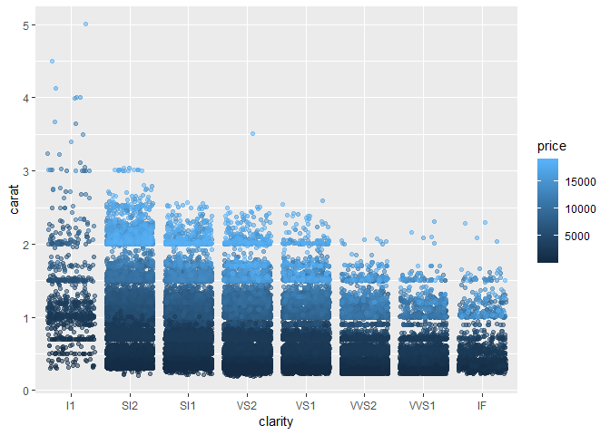

```r
# Dot plot with jittering
ggplot(diamonds, aes(clarity, carat, col = price)) +
  geom_point(alpha = 0.5, position = "jitter")
```

# 4 Geometry

## 4.1 Scatter Plots

Customize the geometry of scatter plots using 37 different options. But the 3 common plots are:

- scatter plots: `points`, `jittter`, `abline`
- bar plots: `histogram`, `bar`, `errorbar`
- line plots: `line`

## 4.2 Scatter plots and jittering

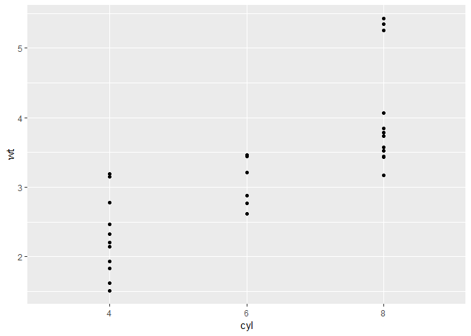

```r
# Shown in the viewer:
ggplot(mtcars, aes(x = cyl, y = wt)) +
  geom_point()
```

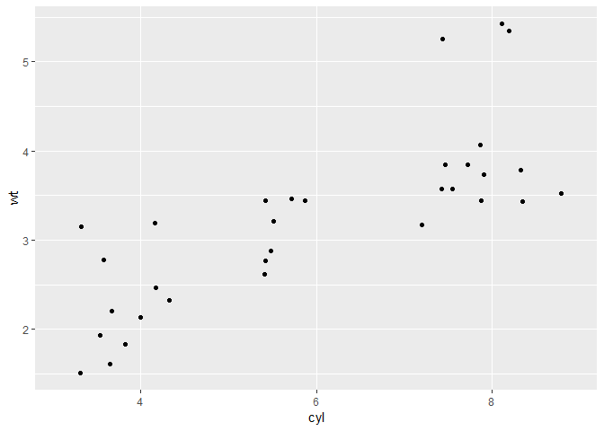

```r
# Solutions:
# 1 - With geom_jitter()
ggplot(mtcars, aes(x = cyl, y = wt)) +
  geom_jitter()
```

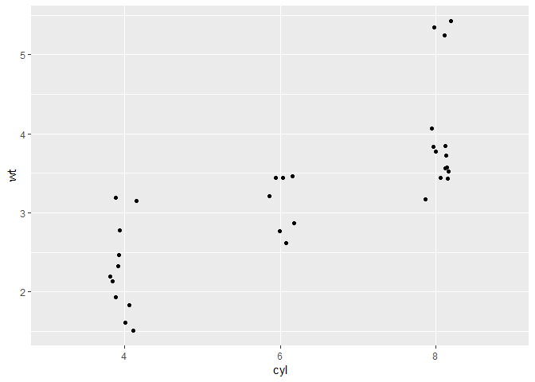

```r
# 2 - Set width in geom_jitter()
ggplot(mtcars, aes(x = cyl, y = wt)) +
  geom_jitter(width = 0.1)
```

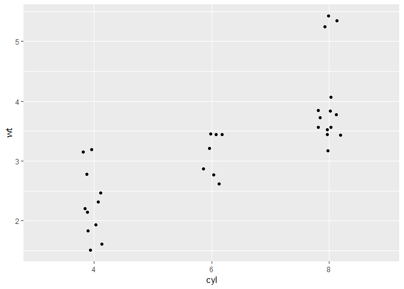

```r
# 3 - Set position = position_jitter() in geom_point() ()
ggplot(mtcars, aes(x = cyl, y = wt)) +
  geom_point(position = position_jitter(0.1))
```

## 4.3 Scatter plot and jittering - part 2

```r
# Examine the structure of Vocab
library(car)
str(Vocab)
```

```
## 'data.frame':    30351 obs. of  4 variables:
##  $ year      : num  1974 1974 1974 1974 1974 ...
##  $ sex       : Factor w/ 2 levels "Female","Male": 2 2 1 1 1 2 2 2 1 1 ...
##  $ education : num  14 16 10 10 12 16 17 10 12 11 ...
##  $ vocabulary: num  9 9 9 5 8 8 9 5 3 5 ...
##  - attr(*, "na.action")= 'omit' Named int  1 2 3 4 5 6 7 8 9 10 ...
##   ..- attr(*, "names")= chr  "19720001" "19720002" "19720003" "19720004" ...
```

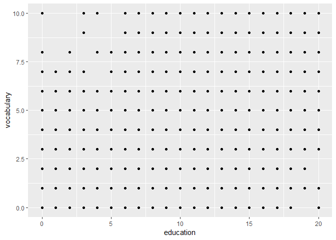

```r
# Basic scatter plot of vocabulary (y) against education (x). Use geom_point()
ggplot(Vocab, aes(education, vocabulary)) +
  geom_point()
```

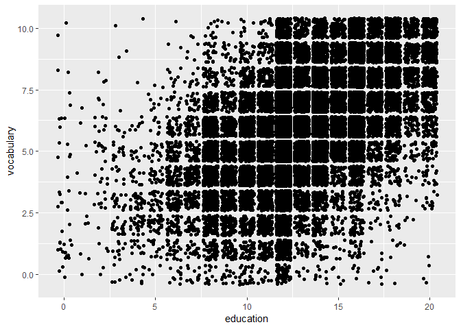

```r
# Use geom_jitter() instead of geom_point()
ggplot(Vocab, aes(education, vocabulary)) +
  geom_jitter()
```

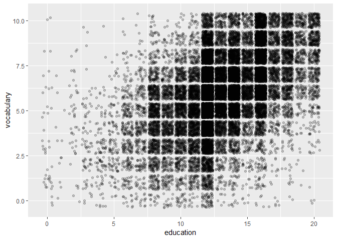

```r
# Using the above plotting command, set alpha to a very low 0.2
ggplot(Vocab, aes(education, vocabulary)) +
  geom_jitter(alpha = 0.2)
```

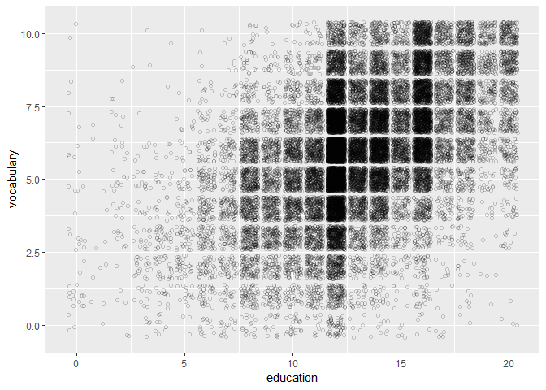

```r
# Using the above plotting command, set the shape to 1
ggplot(Vocab, aes(education, vocabulary)) +
  geom_jitter(alpha = 0.2, shape = 1)
```

##Histograms

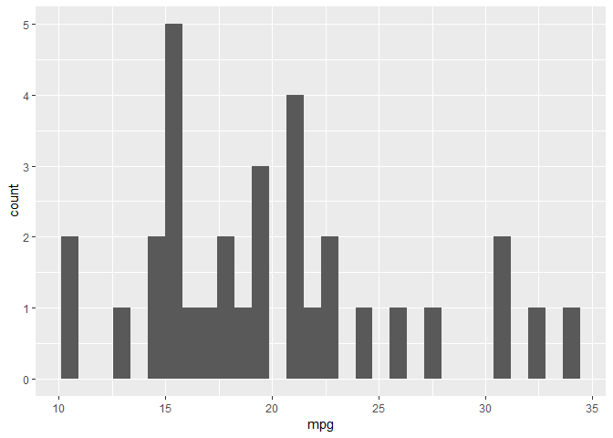

```r
# 1 - Make a univariate histogram
ggplot(mtcars, aes(x = mpg)) +
  geom_histogram()
```

```r
# 2 - Plot 1, plus set binwidth to 1 in the geom layer
ggplot(mtcars, aes(x = mpg)) +
  geom_histogram(binwidth = 1)
```

[output not shown]

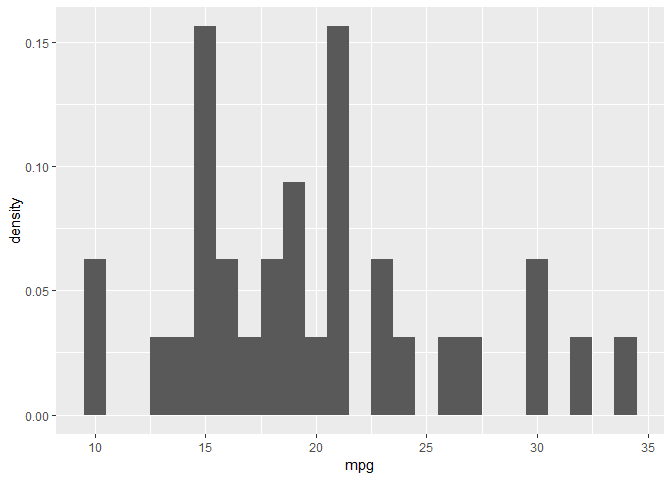

```r
# 3 - Plot 2, plus MAP ..density.. to the y aesthetic (i.e. in a second aes() function)
ggplot(mtcars, aes(x = mpg)) +
  geom_histogram(aes(y = ..density..), binwidth = 1)
```

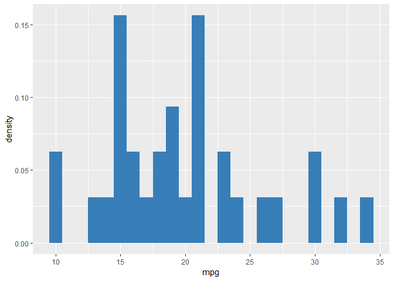

```r
# 4 - plot 3, plus SET the fill attribute to "#377EB8"
ggplot(mtcars, aes(x = mpg)) +
  geom_histogram(aes(y = ..density..), binwidth = 1, fill = "#377EB8")
```